# glucose_summary

2024-08-29

## Sensitivity analysis: Examine TAS2R38-glucose relations by 24HR data

Sensitivity subsample * EUR participants * T2D controls * Complete genotyping, glucose (biochemical) & confounders * Stratified by: complete/missing 24HR data (no energy restriction) * Outliers: glucose values greater than |5SD| from measure mean

Sensitivity analysis sample among all EUR participants

|  | Total |
| --- | --- |
| N (%) | 362458 |
| Genotyping, n(%) | 362075 (99.9%) |
| T2D controls, n(%) | 279805 (77.2%) |
| Complete covariate data, n(%) | 359244 (99.1%) |
| Complete fasting data, n(%) | 362445 (100%) |
| Complete fasting data for <24hr, n(%) | 362419 (100%) |
| Available 24HR data, n (%) | 143928 (39.7%) |
| Total sample for sensitivity analysis, N (%) | 277190 (76.5%) |

Sample characteristics by 24HR data availability

|  | Total | Complete 24HR | No 24HR | P_value | P_trend |
| --- | --- | --- | --- | --- | --- |
| N (%) | 277190 | 113255 (40.9%) | 163935 (59.1%) | - | - |
| TAS2R38 diplotype |  |  |  | 0.6463 | - |
| AVI/AVI | 84572 (33.7%) | 34651 (30.6%) | 49921 (30.5%) |  |  |
| AVI/PAV | 122236 (48.7%) | 49835 (44%) | 72401 (44.2%) |  |  |
| PAV/PAV | 44349 (17.7%) | 18135 (16%) | 26214 (16%) |  |  |
| Age, years | 56.04 ± 8.09 | 55.81 ± 7.92 | 56.21 ± 8.19 | 0 | 0 |
| Sex |  |  |  | 8e-04 | - |
| Male | 125477 (45.3%) | 50837 (44.9%) | 74640 (45.5%) |  |  |
| Female | 151713 (54.7%) | 62418 (55.1%) | 89295 (54.5%) |  |  |
| BMI, kg/m2 | 26.84 ± 4.38 | 26.43 ± 4.26 | 27.13 ± 4.44 | 0 | 0 |
| Smoking |  |  |  | 0 | - |
| Never | 155962 (56.3%) | 65914 (58.2%) | 90048 (54.9%) |  |  |
| Previous | 95275 (34.4%) | 39503 (34.9%) | 55772 (34%) |  |  |
| Current | 25953 (9.4%) | 7838 (6.9%) | 18115 (11.1%) |  |  |
| Physical Activity, MET/wk |  |  |  | 0 | - |
| Low | 63094 (22.8%) | 26037 (23%) | 37057 (22.6%) |  |  |
| Moderate | 156685 (56.5%) | 65590 (57.9%) | 91095 (55.6%) |  |  |
| High | 57411 (20.7%) | 21628 (19.1%) | 35783 (21.8%) |  |  |
| Alcohol Frequency |  |  |  | 0 | - |
| Daily or almost daily | 62057 (22.4%) | 27745 (24.5%) | 34312 (20.9%) |  |  |
| 3-4 per week | 70016 (25.3%) | 30128 (26.6%) | 39888 (24.3%) |  |  |
| 1-2 per week | 72936 (26.3%) | 28352 (25%) | 44584 (27.2%) |  |  |
| 1-3 per month | 29723 (10.7%) | 11750 (10.4%) | 17973 (11%) |  |  |
| Special occasions only | 26363 (9.5%) | 9495 (8.4%) | 16868 (10.3%) |  |  |
| Never1 | 16095 (5.8%) | 5785 (5.1%) | 10310 (6.3%) |  |  |
| Education Level |  |  |  | 0 | - |
| College or university degree | 94110 (34.2%) | 49254 (43.5%) | 44856 (27.4%) |  |  |
| NVQ/HND or equivalent | 17489 (6.4%) | 5942 (5.2%) | 11547 (7%) |  |  |
| Other professional qualifications | 13789 (5%) | 5413 (4.8%) | 8376 (5.1%) |  |  |
| A/AS levels or equivalent | 32770 (11.9%) | 15219 (13.4%) | 17551 (10.7%) |  |  |
| O/GCSE levels or equivalent | 60314 (21.9%) | 23399 (20.7%) | 36915 (22.5%) |  |  |
| CSEs or equivalent | 15251 (5.5%) | 4801 (4.2%) | 10450 (6.4%) |  |  |
| None of the above | 41146 (15%) | 8849 (7.8%) | 32297 (19.7%) |  |  |
| Income Level |  |  |  | 0 | - |
| lt_18000 | 46852 (19.4%) | 14081 (12.4%) | 32771 (20%) |  |  |
| from_18000_to_30999 | 59684 (24.8%) | 24300 (21.5%) | 35384 (21.6%) |  |  |
| from_31000_to_51999 | 65731 (27.3%) | 29697 (26.2%) | 36034 (22%) |  |  |
| from_52000_to_100000 | 54090 (22.4%) | 26369 (23.3%) | 27721 (16.9%) |  |  |
| gt_100000 | 14609 (6.1%) | 7829 (6.9%) | 6780 (4.1%) |  |  |

## Are the differences in glucose by 24HR due to *assay performance*?

#### Look at differences in *Glucose*

Glucose at v0 & v1 by 24HR data

|  | Total | Complete 24HR | No 24HR | P_value |
| --- | --- | --- | --- | --- |
| N (%) | 277190 | 113255 (40.9%) | 163935 (59.1%) | - |
| Blood glucose at v0, mmol/L | 4.913 ± 0.584 | 4.934 ± 0.578 | 4.898 ± 0.588 | 0 |
| Blood glucose at v1, mmol/L | 4.899 ± 0.511 | 4.904 ± 0.515 | 4.893 ± 0.505 | 0.313898687958124 |

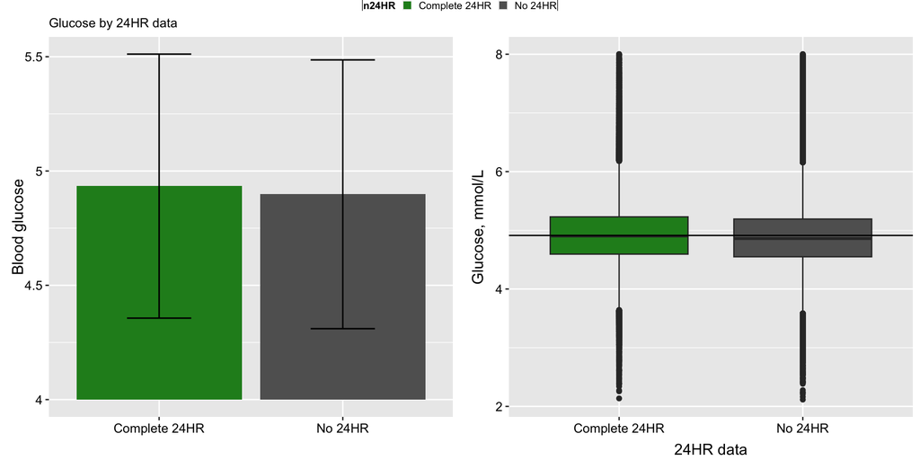

Glucose at v0 & v1 by fasting category and 24HR data

|  | Total | No 24HR | Complete 24HR | P_value |
| --- | --- | --- | --- | --- |
| N (%) | 73372 | 43987 (60%) | 29385 (40%) | - |
| 0to2hr glucose at v0, mmol/L | 4.953 ± 0.743 | 4.944 ± 0.744 | 4.968 ± 0.741 | 7.8e-05 |
| 0to2hr glucose at v1, mmol/L | 4.884 ± 0.509 | 4.86 ± 0.485 | 4.9 ± 0.523 | 0.060389 |
| N (%)1 | 82160 | 47066 (57.3%) | 35094 (42.7%) | - |
| 3hr glucose at v0, mmol/L | 4.893 ± 0.561 | 4.878 ± 0.564 | 4.913 ± 0.556 | 0 |
| 3hr glucose at v1, mmol/L | 4.898 ± 0.505 | 4.896 ± 0.514 | 4.899 ± 0.5 | 0.854486 |
| N (%)2 | 59898 | 34457 (57.5%) | 25441 (42.5%) | - |
| 4hr glucose at v0, mmol/L | 4.9 ± 0.49 | 4.879 ± 0.496 | 4.928 ± 0.482 | 0 |
| 4hr glucose at v1, mmol/L | 4.917 ± 0.523 | 4.927 ± 0.519 | 4.91 ± 0.525 | 0.485641 |
| N (%)3 | 32594 | 19389 (59.5%) | 13205 (40.5%) | - |
| 5hr glucose at v0, mmol/L | 4.889 ± 0.467 | 4.872 ± 0.471 | 4.915 ± 0.46 | 0 |
| 5hr glucose at v1, mmol/L | 4.908 ± 0.521 | 4.886 ± 0.52 | 4.921 ± 0.521 | 0.307238 |
| N (%)4 | 29166 | 19036 (65.3%) | 10130 (34.7%) | - |
| 6+hr glucose at v0, mmol/L | 4.92 ± 0.476 | 4.904 ± 0.482 | 4.951 ± 0.463 | 0 |
| 6+hr glucose at v1, mmol/L | 4.894 ± 0.498 | 4.902 ± 0.486 | 4.888 ± 0.509 | 0.676764 |

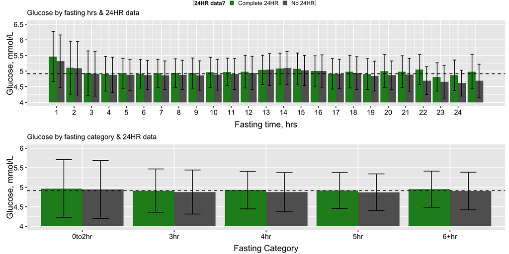

Summary

- Glucose is *significantly* higher for participants that completed 24HR vs. those that didn’t, at baseline (visit 0) but NOT at visit 1 (~5 years later).
- At visit 0, glucose is *significantly* higher for those that completed 24HR vs. those that didn’t for *at all categorical fasting windows* at visit 0 but NOT at visit 1.

### Do differences in assay performance by 24HR explain any differences in glucose?

**Estimated fractional dilution**

Description of blood assays by 24HR data

|  | Total | Complete 24HR | No 24HR | P_value |
| --- | --- | --- | --- | --- |
| N (%) | 277190 | 113255 (40.9%) | 163935 (59.1%) | - |
| Sample dilution at v0, % | 99.9253 ± 0.3775 | 100.0108 ± 0.4081 | 99.8662 ± 0.3426 | 0 |
| Sample dilution at v1, % | 99.8826 ± 0.2338 | 99.8775 ± 0.2342 | 99.8907 ± 0.2328 | 0.0086130414 |

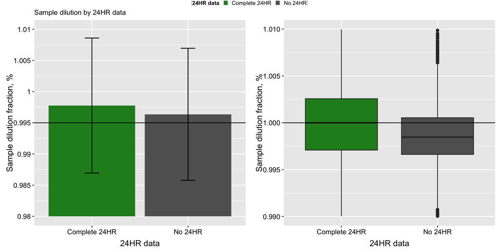

Sample dilution (%) at v0 & v1 by fasting category and 24HR data

|  | Total | No 24HR | Complete 24HR | P_value |
| --- | --- | --- | --- | --- |
| N (%) | 73372 | 43987 (60%) | 29385 (40%) | - |
| 0to2hr sample dilution at v0, % | 99.876 ± 0.328 | 99.833 ± 0.301 | 99.942 ± 0.356 | 0 |
| 0to2hr sample dilution at v1, % | 99.882 ± 0.227 | 99.891 ± 0.224 | 99.876 ± 0.228 | 0.111782 |
| N (%)1 | 82160 | 47066 (57.3%) | 35094 (42.7%) | - |
| 3hr sample dilution at v0, % | 99.926 ± 0.374 | 99.865 ± 0.338 | 100.009 ± 0.403 | 0 |
| 3hr sample dilution at v1, % | 99.882 ± 0.237 | 99.888 ± 0.237 | 99.879 ± 0.237 | 0.291553 |
| N (%)2 | 59898 | 34457 (57.5%) | 25441 (42.5%) | - |
| 4hr sample dilution at v0, % | 99.967 ± 0.405 | 99.895 ± 0.367 | 100.063 ± 0.433 | 0 |
| 4hr sample dilution at v1, % | 99.877 ± 0.236 | 99.885 ± 0.233 | 99.872 ± 0.237 | 0.225582 |
| N (%)3 | 32594 | 19389 (59.5%) | 13205 (40.5%) | - |
| 5hr sample dilution at v0, % | 99.964 ± 0.41 | 99.898 ± 0.375 | 100.06 ± 0.44 | 0 |
| 5hr sample dilution at v1, % | 99.891 ± 0.239 | 99.895 ± 0.24 | 99.888 ± 0.238 | 0.643748 |
| N (%)4 | 29166 | 19036 (65.3%) | 10130 (34.7%) | - |
| 6+hr sample dilution at v0, % | 99.917 ± 0.391 | 99.862 ± 0.357 | 100.018 ± 0.429 | 0 |
| 6+hr sample dilution at v1, % | 99.889 ± 0.231 | 99.901 ± 0.233 | 99.878 ± 0.229 | 0.137334 |

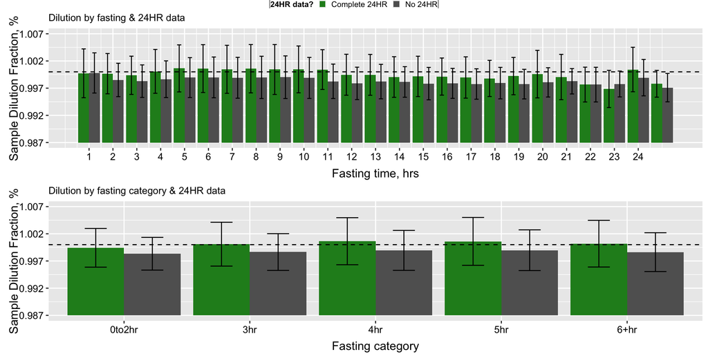

**Aliquot**

Description of blood assays by 24HR data

|  | Total | Complete 24HR | No 24HR | P_value |
| --- | --- | --- | --- | --- |
| N (%) | 277190 | 113255 (40.9%) | 163935 (59.1%) | - |
| Aliquot # at v0 |  |  |  | 2.0268e-06 |
| Manual | 5062 (1.9%) | 2064 (1.8%) | 2998 (1.8%) |  |
| Aliquot 1 | 237955 (89.3%) | 96960 (85.6%) | 140995 (86%) |  |
| Aliquot 2 | 17044 (6.4%) | 7270 (6.4%) | 9774 (6%) |  |
| Aliquot 3 | 6321 (2.4%) | 2493 (2.2%) | 3828 (2.3%) |  |
| Aliquot # at v1 |  |  |  | 0.4152015864 |
| Manual1 | 3195 (30.4%) | 1923 (1.7%) | 1272 (0.8%) |  |
| Aliquot 11 | 6234 (59.4%) | 3809 (3.4%) | 2425 (1.5%) |  |
| Aliquot 21 | 754 (7.2%) | 478 (0.4%) | 276 (0.2%) |  |
| Aliquot 31 | 318 (3%) | 197 (0.2%) | 121 (0.1%) |  |

Do glucose and dilution fraction differ by aliquot number and 24HR

|  | Total | Complete 24HR | No 24HR | P_value |
| --- | --- | --- | --- | --- |
| N (%) | 5062 | 2064 (40.8%) | 2998 (59.2%) | - |
| Manual : glucose at v0 | 4.9654 ± 0.5802 | 4.9798 ± 0.586 | 4.9556 ± 0.5761 | 0.1407041314 |
| Manual : sample dilution at v0 | 100 ± 0 | 100 ± 0 | 100 ± 0 | 0.2279428155 |
| N (%)1 | 237955 | 96960 (40.7%) | 140995 (59.3%) | - |
| Aliquot 1 : glucose at v0 | 4.9105 ± 0.5845 | 4.9316 ± 0.5783 | 4.8961 ± 0.5883 | 0 |
| Aliquot 1 : sample dilution at v0 | 99.9315 ± 0.3772 | 100.0239 ± 0.4052 | 99.8684 ± 0.3427 | 0 |
| N (%)2 | 17044 | 7270 (42.7%) | 9774 (57.3%) | - |
| Aliquot 2 : glucose at v0 | 4.9887 ± 0.5402 | 4.997 ± 0.5259 | 4.9771 ± 0.5594 | 0.2892727384 |
| Aliquot 2 : sample dilution at v0 | 99.3633 ± 0.2345 | 99.3775 ± 0.2317 | 99.3429 ± 0.2369 | 3.66583e-05 |

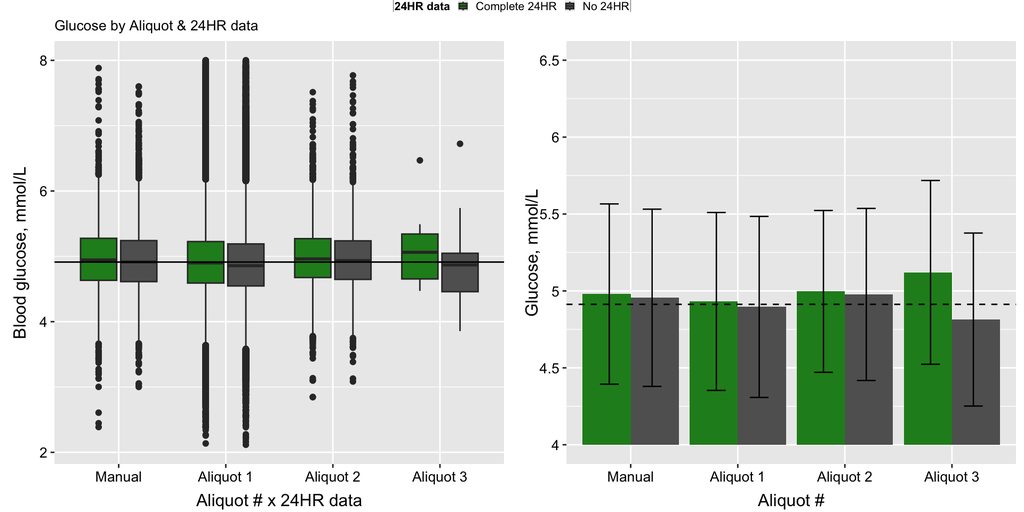

*Note* the significant differene in sample dilution b/w 24HR groups at both time points; but much more so at v0”)

### Recalling differences in SES by 24HR

Re-examing SES differences by 24HR and whether this captures the influence of 24HR on glucose

Description of SES by 24HR data

|  | Total | Complete 24HR | No 24HR | P_value |
| --- | --- | --- | --- | --- |
| N (%) | 277190 | 113255 (40.9%) | 163935 (59.1%) | - |
| Income Level |  |  |  | 0 |
| lt_18000 | 46852 (19.4%) | 14081 (12.4%) | 32771 (20%) |  |
| from_18000_to_30999 | 59684 (24.8%) | 24300 (21.5%) | 35384 (21.6%) |  |
| from_31000_to_51999 | 65731 (27.3%) | 29697 (26.2%) | 36034 (22%) |  |
| from_52000_to_100000 | 54090 (22.4%) | 26369 (23.3%) | 27721 (16.9%) |  |
| gt_100000 | 14609 (6.1%) | 7829 (6.9%) | 6780 (4.1%) |  |
| Education Level |  |  |  | 0 |
| College or university degree | 94110 (34.2%) | 49254 (43.5%) | 44856 (27.4%) |  |
| NVQ/HND or equivalent | 17489 (6.4%) | 5942 (5.2%) | 11547 (7%) |  |
| Other professional qualifications | 13789 (5%) | 5413 (4.8%) | 8376 (5.1%) |  |
| A/AS levels or equivalent | 32770 (11.9%) | 15219 (13.4%) | 17551 (10.7%) |  |
| O/GCSE levels or equivalent | 60314 (21.9%) | 23399 (20.7%) | 36915 (22.5%) |  |
| CSEs or equivalent | 15251 (5.5%) | 4801 (4.2%) | 10450 (6.4%) |  |
| None of the above | 41146 (15%) | 8849 (7.8%) | 32297 (19.7%) |  |

#### Statistical comparisons

Effect of 24hr on glucose is substantially (but not fully) attenuated when adjusting for assay performance parameters

| Model | Exposure | N | Beta_95CI | P | F.test_P |
| --- | --- | --- | --- | --- | --- |
| AgeSex | Complete 24HR | 98406 | NA (NA, NA) | - | 0 |
| AgeSex | No 24HR | 142972 | -0.04 (-0.044, -0.035) | 2.43117604402496e-61 | - |
| AgeSexFasting | Complete 24HR | 98406 | NA (NA, NA) | - | 0 |
| AgeSexFasting | No 24HR | 142972 | -0.039 (-0.044, -0.035) | 2.45640123931101e-60 | - |
| Dilution/Aliquot | Complete 24HR | 98013 | NA (NA, NA) | - | 0 |
| Dilution/Aliquot | No 24HR | 141869 | -0.008 (-0.013, -0.003) | 0.00123288152286333 | - |
| +SES | Complete 24HR | 88432 | NA (NA, NA) | - | 0 |
| +SES | No 24HR | 119638 | -0.014 (-0.019, -0.009) | 1.69484558419885e-07 | - |

Summary

# Sensitivity Models

## Run sensitivity models adjusting for SES

TAS2R38 diplotype & RG with SES adjustment

| Model | Exposure | N | Beta_95CI | P | F.test_P | T.test_P |
| --- | --- | --- | --- | --- | --- | --- |
| Base | AVI/AVI | 73524 | NA (NA, NA) | - | 0.05576 | 0.019962 |
| Base | AVI/PAV | 106591 | -0.003 (-0.009, 0.002) | 0.255965392389088 | - | - |
| Base | PAV/PAV | 38573 | -0.009 (-0.016, -0.001) | 0.0177718294423106 | - | - |
| Diet | AVI/AVI | 73524 | NA (NA, NA) | - | 0.053775 | 0.041924 |
| Diet | AVI/PAV | 106591 | -0.003 (-0.008, 0.003) | 0.301985312958939 | - | - |
| Diet | PAV/PAV | 38573 | -0.007 (-0.015, 0) | 0.0393244760869308 | - | - |
| SES | AVI/AVI | 63828 | NA (NA, NA) | - | 0.045638 | 0.029988 |
| SES | AVI/PAV | 92420 | -0.004 (-0.009, 0.002) | 0.234313185005023 | - | - |
| SES | PAV/PAV | 33391 | -0.008 (-0.016, -0.001) | 0.0297875390353215 | - | - |
| Assay | AVI/AVI | 63439 | NA (NA, NA) | - | 0.035163 | 0.015031 |
| Assay | AVI/PAV | 91830 | -0.004 (-0.009, 0.002) | 0.210262251354732 | - | - |
| Assay | PAV/PAV | 33193 | -0.009 (-0.017, -0.002) | 0.013977926073765 | - | - |

TAS2R38 diplotype & 2hr glucose with SES adjustment

| Model | Exposure | N | Beta_95CI | P | F.test_P | T.test_P |
| --- | --- | --- | --- | --- | --- | --- |
| Base | AVI/AVI | 19489 | NA (NA, NA) | - | 0.018076 | 0.003995 |
| Base | AVI/PAV | 28110 | -0.014 (-0.028, -0.001) | 0.0358447144570994 | - | - |
| Base | PAV/PAV | 10053 | -0.025 (-0.042, -0.007) | 0.00640367616042155 | - | - |
| Diet | AVI/AVI | 19489 | NA (NA, NA) | - | 0.016755 | 0.007854 |
| Diet | AVI/PAV | 28110 | -0.013 (-0.027, 0) | 0.0505110841891067 | - | - |
| Diet | PAV/PAV | 10053 | -0.022 (-0.04, -0.005) | 0.0119890661375582 | - | - |
| SES | AVI/AVI | 17253 | NA (NA, NA) | - | 0.003538 | 0.001053 |
| SES | AVI/PAV | 25015 | -0.015 (-0.029, -0.001) | 0.0346696558678994 | - | - |
| SES | PAV/PAV | 8870 | -0.03 (-0.049, -0.012) | 0.00144533807245786 | - | - |
| Assay | AVI/AVI | 17130 | NA (NA, NA) | - | 0.003194 | 0.000674 |
| Assay | AVI/PAV | 24838 | -0.016 (-0.03, -0.002) | 0.0222107064151201 | - | - |
| Assay | PAV/PAV | 8814 | -0.031 (-0.049, -0.012) | 0.00104687242129102 | - | - |

TAS2R38 diplotype & HbA1c with SES adjustment

| Model | Exposure | N | Beta_95CI | P | F.test_P | T.test_P |
| --- | --- | --- | --- | --- | --- | --- |
| Base | AVI/AVI | 73524 | NA (NA, NA) | - | 0.220218 | 0.32931 |
| Base | AVI/PAV | 106591 | 0.002 (0, 0.005) | 0.0935983071380544 | - | - |
| Base | PAV/PAV | 38573 | 0.001 (-0.002, 0.004) | 0.518847986113691 | - | - |
| Diet | AVI/AVI | 73524 | NA (NA, NA) | - | 0.212088 | 0.473254 |
| Diet | AVI/PAV | 106591 | 0.002 (-0.001, 0.004) | 0.133415524817373 | - | - |
| Diet | PAV/PAV | 38573 | 0.001 (-0.003, 0.004) | 0.691832590503497 | - | - |
| SES | AVI/AVI | 63828 | NA (NA, NA) | - | 0.43849 | 0.531695 |
| SES | AVI/PAV | 92420 | 0.001 (-0.001, 0.004) | 0.306730077102523 | - | - |
| SES | PAV/PAV | 33391 | 0.001 (-0.003, 0.004) | 0.668648031796634 | - | - |
| Assay | AVI/AVI | 63439 | NA (NA, NA) | - | 0.391758 | 0.484747 |
| Assay | AVI/PAV | 91830 | 0.001 (-0.001, 0.004) | 0.261816859820659 | - | - |
| Assay | PAV/PAV | 33193 | 0.001 (-0.003, 0.004) | 0.628401404434394 | - | - |

## Run sensitivity models adjusting for Fiber-to-Carb ratio, among participants with 24HR data

### Additionally adjust for assay performance metrics, given apparent differences between groups

Based on the differenes in assay performance between the two subgroups, and the effect these differences seem to have on glucose levels between the strata, we ran sensitivity models to see what happens to the overall effect when we additionally adjusting for assay performance, and if the apparent differences by 24HR are attenuated when adjusting, as well.

**Stratified models by 24HR data**

TAS2R38 diplotype with RG & 2hr glucose, adjusting for Fiber-to-Carbohydrate ratio

| Model | Exposure | N | Beta_95CI | P | F.test_P | T.test_P |
| --- | --- | --- | --- | --- | --- | --- |
| Has 24HR: RG~Assay | AVI/AVI | 27098 | NA (NA, NA) | - | 0.122548 | 0.049633 |
| Has 24HR: RG~Assay | AVI/PAV | 38882 | -0.007 (-0.015, 0.002) | 0.133028770052777 | - | - |
| Has 24HR: RG~Assay | PAV/PAV | 14126 | -0.011 (-0.022, 0.001) | 0.0657419319545201 | - | - |
| Has 24HR: RG~SES+Fib2Carb | AVI/AVI | 27164 | NA (NA, NA) | - | 0.133672 | 0.071383 |
| Has 24HR: RG~SES+Fib2Carb | AVI/PAV | 38984 | -0.007 (-0.015, 0.002) | 0.137122751083967 | - | - |
| Has 24HR: RG~SES+Fib2Carb | PAV/PAV | 14164 | -0.01 (-0.021, 0.002) | 0.0971369667151431 | - | - |
| Has 24HR: RG~Fib2Carb+Assay | AVI/AVI | 27050 | NA (NA, NA) | - | 0.111757 | 0.047735 |
| Has 24HR: RG~Fib2Carb+Assay | AVI/PAV | 38827 | -0.007 (-0.016, 0.002) | 0.114758954145502 | - | - |
| Has 24HR: RG~Fib2Carb+Assay | PAV/PAV | 14109 | -0.011 (-0.022, 0.001) | 0.0661097718257744 | - | - |
| Has 24HR: 2hr Glu~Assay | AVI/AVI | 7066 | NA (NA, NA) | - | 0.066552 | 0.018681 |
| Has 24HR: 2hr Glu~Assay | AVI/PAV | 10263 | -0.019 (-0.041, 0.003) | 0.0860314182880016 | - | - |
| Has 24HR: 2hr Glu~Assay | PAV/PAV | 3626 | -0.033 (-0.061, -0.004) | 0.0260278494764421 | - | - |
| Has 24HR: 2hr Glu~SES+Fib2Carb | AVI/AVI | 7088 | NA (NA, NA) | - | 0.065616 | 0.016797 |
| Has 24HR: 2hr Glu~SES+Fib2Carb | AVI/PAV | 10294 | -0.02 (-0.042, 0.002) | 0.0693199705494735 | - | - |
| Has 24HR: 2hr Glu~SES+Fib2Carb | PAV/PAV | 3638 | -0.033 (-0.062, -0.004) | 0.0249864931847259 | - | - |
| Has 24HR: 2hr Glu~Fib2Carb+Assay | AVI/AVI | 7055 | NA (NA, NA) | - | 0.061603 | 0.017977 |
| Has 24HR: 2hr Glu~Fib2Carb+Assay | AVI/PAV | 10247 | -0.02 (-0.041, 0.002) | 0.0762624886043597 | - | - |
| Has 24HR: 2hr Glu~Fib2Carb+Assay | PAV/PAV | 3623 | -0.033 (-0.061, -0.004) | 0.0260397813800397 | - | - |

TAS2R38 diplotype with RG & 2hr glucose, in subset without 24HR data (comparison)

| Model | Exposure | N | Beta_95CI | P | F.test_P | T.test_P |
| --- | --- | --- | --- | --- | --- | --- |
| No 24HR: RG~Assay | AVI/AVI | 36341 | NA (NA, NA) | - | 0.191504 | 0.132223 |
| No 24HR: RG~Assay | AVI/PAV | 52948 | -0.001 (-0.009, 0.006) | 0.734195757179448 | - | - |
| No 24HR: RG~Assay | PAV/PAV | 19067 | -0.008 (-0.019, 0.002) | 0.0992086208909289 | - | - |
| No 24HR: 2hr Glu~Base | AVI/AVI | 11749 | NA (NA, NA) | - | 0.202324 | 0.09641 |
| No 24HR: 2hr Glu~Base | AVI/PAV | 16926 | -0.011 (-0.029, 0.006) | 0.196796229239813 | - | - |
| No 24HR: 2hr Glu~Base | PAV/PAV | 6047 | -0.018 (-0.041, 0.005) | 0.120950810145678 | - | - |
| No 24HR: 2hr Glu~Diet | AVI/AVI | 11749 | NA (NA, NA) | - | 0.195752 | 0.13905 |
| No 24HR: 2hr Glu~Diet | AVI/PAV | 16926 | -0.009 (-0.026, 0.008) | 0.295732972072024 | - | - |
| No 24HR: 2hr Glu~Diet | PAV/PAV | 6047 | -0.016 (-0.039, 0.006) | 0.158327340162244 | - | - |
| No 24HR: 2hr Glu~SES | AVI/AVI | 10153 | NA (NA, NA) | - | 0.045054 | 0.024233 |
| No 24HR: 2hr Glu~SES | AVI/PAV | 14705 | -0.012 (-0.03, 0.007) | 0.213628988613907 | - | - |
| No 24HR: 2hr Glu~SES | PAV/PAV | 5229 | -0.028 (-0.052, -0.004) | 0.0242013406183081 | - | - |
| No 24HR: 2hr Glu~Assay | AVI/AVI | 10064 | NA (NA, NA) | - | 0.043209 | 0.015237 |
| No 24HR: 2hr Glu~Assay | AVI/PAV | 14575 | -0.014 (-0.032, 0.004) | 0.133287406705519 | - | - |
| No 24HR: 2hr Glu~Assay | PAV/PAV | 5188 | -0.029 (-0.054, -0.005) | 0.0173695110794611 | - | - |

## Run sensitivity models, restricting to samples analyzed from Aliquot 1

### Aliquot 1 had the least dilution, relative to other aliquots

TAS2R38 diplotype & RG with assay perf adjustment

| Model | Exposure | N | Beta_95CI | P | F.test_P | T.test_P |
| --- | --- | --- | --- | --- | --- | --- |
| Base | AVI/AVI | 70874 | NA (NA, NA) | - | 0.062334 | 0.023129 |
| Base | AVI/PAV | 102878 | -0.003 (-0.008, 0.003) | 0.338112770566474 | - | - |
| Base | PAV/PAV | 37189 | -0.009 (-0.016, -0.001) | 0.0184013302233159 | - | - |
| Diet | AVI/AVI | 70874 | NA (NA, NA) | - | 0.060181 | 0.048379 |
| Diet | AVI/PAV | 102878 | -0.002 (-0.008, 0.003) | 0.399207408513763 | - | - |
| Diet | PAV/PAV | 37189 | -0.008 (-0.015, 0) | 0.040767106865517 | - | - |
| SES | AVI/AVI | 61507 | NA (NA, NA) | - | 0.063757 | 0.04009 |
| SES | AVI/PAV | 89205 | -0.003 (-0.009, 0.003) | 0.312096264227864 | - | - |
| SES | PAV/PAV | 32182 | -0.008 (-0.016, -0.001) | 0.0367303909228387 | - | - |
| Assay | AVI/AVI | 61183 | NA (NA, NA) | - | 0.055794 | 0.021758 |
| Assay | AVI/PAV | 88710 | -0.003 (-0.009, 0.003) | 0.285508491516904 | - | - |
| Assay | PAV/PAV | 32024 | -0.009 (-0.017, -0.002) | 0.0186370899056104 | - | - |
| SES+Fib2Carb | AVI/AVI | 26030 | NA (NA, NA) | - | 0.174396 | 0.077787 |
| SES+Fib2Carb | AVI/PAV | 37397 | -0.006 (-0.015, 0.003) | 0.179298088002748 | - | - |
| SES+Fib2Carb | PAV/PAV | 13585 | -0.01 (-0.022, 0.002) | 0.0978440529199615 | - | - |
| Fib2Carb+Assay | AVI/AVI | 25944 | NA (NA, NA) | - | 0.139037 | 0.046101 |
| Fib2Carb+Assay | AVI/PAV | 37277 | -0.007 (-0.016, 0.002) | 0.148478378331116 | - | - |
| Fib2Carb+Assay | PAV/PAV | 13547 | -0.011 (-0.023, 0) | 0.0582696173665983 | - | - |

TAS2R38 diplotype & 2hr glucose with assay perf adjustment

| Model | Exposure | N | Beta_95CI | P | F.test_P | T.test_P |
| --- | --- | --- | --- | --- | --- | --- |
| Base | AVI/AVI | 18860 | NA (NA, NA) | - | 0.037329 | 0.007495 |
| Base | AVI/PAV | 27232 | -0.013 (-0.026, 0.001) | 0.0672543129096688 | - | - |
| Base | PAV/PAV | 9773 | -0.024 (-0.042, -0.006) | 0.0101952914112553 | - | - |
| Diet | AVI/AVI | 18860 | NA (NA, NA) | - | 0.035047 | 0.013833 |
| Diet | AVI/PAV | 27232 | -0.011 (-0.025, 0.002) | 0.0990194287985127 | - | - |
| Diet | PAV/PAV | 9773 | -0.022 (-0.039, -0.004) | 0.0175311730074844 | - | - |
| SES | AVI/AVI | 16700 | NA (NA, NA) | - | 0.006747 | 0.001833 |
| SES | AVI/PAV | 24241 | -0.013 (-0.028, 0.001) | 0.0653561112512255 | - | - |
| SES | PAV/PAV | 8625 | -0.03 (-0.048, -0.011) | 0.00206917456800897 | - | - |
| Assay | AVI/AVI | 16599 | NA (NA, NA) | - | 0.005807 | 0.001062 |
| Assay | AVI/PAV | 24095 | -0.015 (-0.029, -0.001) | 0.0418706831378643 | - | - |
| Assay | PAV/PAV | 8576 | -0.031 (-0.049, -0.012) | 0.00134451673542425 | - | - |
| SES+Fib2Carb | AVI/AVI | 6843 | NA (NA, NA) | - | 0.107356 | 0.023826 |
| SES+Fib2Carb | AVI/PAV | 9937 | -0.018 (-0.04, 0.004) | 0.116296200524566 | - | - |
| SES+Fib2Carb | PAV/PAV | 3538 | -0.032 (-0.062, -0.003) | 0.0304683619254241 | - | - |
| Fib2Carb+Assay | AVI/AVI | 6817 | NA (NA, NA) | - | 0.090322 | 0.020682 |
| Fib2Carb+Assay | AVI/PAV | 9901 | -0.017 (-0.04, 0.005) | 0.122146319756737 | - | - |
| Fib2Carb+Assay | PAV/PAV | 3526 | -0.033 (-0.062, -0.004) | 0.0254779250901108 | - | - |

TAS2R38 diplotype & HbA1c with assay perf adjustment

| Model | Exposure | N | Beta_95CI | P | F.test_P | T.test_P |
| --- | --- | --- | --- | --- | --- | --- |
| Base | AVI/AVI | 70874 | NA (NA, NA) | - | 0.159495 | 0.258538 |
| Base | AVI/PAV | 102878 | 0.002 (0, 0.005) | 0.0767733224749456 | - | - |
| Base | PAV/PAV | 37189 | 0.001 (-0.002, 0.005) | 0.4253221183165 | - | - |
| Diet | AVI/AVI | 70874 | NA (NA, NA) | - | 0.152385 | 0.394538 |
| Diet | AVI/PAV | 102878 | 0.002 (0, 0.004) | 0.115530514631767 | - | - |
| Diet | PAV/PAV | 37189 | 0.001 (-0.002, 0.004) | 0.595492197876068 | - | - |
| SES | AVI/AVI | 61507 | NA (NA, NA) | - | 0.32131 | 0.43814 |
| SES | AVI/PAV | 89205 | 0.002 (-0.001, 0.004) | 0.261785015441283 | - | - |
| SES | PAV/PAV | 32182 | 0.001 (-0.002, 0.004) | 0.566737971430629 | - | - |
| Assay | AVI/AVI | 61183 | NA (NA, NA) | - | 0.283022 | 0.374343 |
| Assay | AVI/PAV | 88710 | 0.002 (-0.001, 0.004) | 0.230801265166363 | - | - |
| Assay | PAV/PAV | 32024 | 0.001 (-0.002, 0.005) | 0.495215259449991 | - | - |
| SES+Fib2Carb | AVI/AVI | 26030 | NA (NA, NA) | - | 0.324594 | 0.377915 |
| SES+Fib2Carb | AVI/PAV | 37397 | 0.001 (-0.003, 0.005) | 0.782594655896954 | - | - |
| SES+Fib2Carb | PAV/PAV | 13585 | 0.003 (-0.003, 0.008) | 0.345577185039223 | - | - |
| Fib2Carb+Assay | AVI/AVI | 25944 | NA (NA, NA) | - | 0.320721 | 0.353746 |
| Fib2Carb+Assay | AVI/PAV | 37277 | 0.001 (-0.003, 0.005) | 0.733208726446348 | - | - |
| Fib2Carb+Assay | PAV/PAV | 13547 | 0.003 (-0.003, 0.008) | 0.3285020170856 | - | - |

## Run stratified analyses by sex

TAS2R38 diplotype & RG by sex

| Model | Exposure | N | Beta_95CI | P | F.test_P | T.test_P |
| --- | --- | --- | --- | --- | --- | --- |
| Female: Base | AVI/AVI | 39922 | NA (NA, NA) | - | 0.533015 | 0.331205 |
| Female: Base | AVI/PAV | 57906 | -0.001 (-0.009, 0.006) | 0.713471467369054 | - | - |
| Female: Base | PAV/PAV | 20892 | -0.005 (-0.015, 0.005) | 0.307198950457215 | - | - |
| Female: Diet | AVI/AVI | 39922 | NA (NA, NA) | - | 0.529195 | 0.396765 |
| Female: Diet | AVI/PAV | 57906 | -0.001 (-0.008, 0.006) | 0.760666693956755 | - | - |
| Female: Diet | PAV/PAV | 20892 | -0.004 (-0.014, 0.005) | 0.37072811928375 | - | - |
| Female: SES | AVI/AVI | 33489 | NA (NA, NA) | - | 0.480209 | 0.32828 |
| Female: SES | AVI/PAV | 48578 | -0.003 (-0.011, 0.005) | 0.466603466105092 | - | - |
| Female: SES | PAV/PAV | 17487 | -0.005 (-0.015, 0.006) | 0.356237137121334 | - | - |
| Female: Assay | AVI/AVI | 33279 | NA (NA, NA) | - | 0.461764 | 0.172482 |
| Female: Assay | AVI/PAV | 48237 | -0.003 (-0.011, 0.004) | 0.39274163626586 | - | - |
| Female: Assay | PAV/PAV | 17387 | -0.007 (-0.017, 0.003) | 0.181967698713842 | - | - |
| Female: SES+Fib2Carb | AVI/AVI | 14412 | NA (NA, NA) | - | 0.371576 | 0.41326 |
| Female: SES+Fib2Carb | AVI/PAV | 20781 | -0.008 (-0.019, 0.004) | 0.219963821572436 | - | - |
| Female: SES+Fib2Carb | PAV/PAV | 7569 | -0.005 (-0.02, 0.011) | 0.552611071462557 | - | - |
| Female: Fib2Carb+Assay | AVI/AVI | 14358 | NA (NA, NA) | - | 0.384416 | 0.271295 |
| Female: Fib2Carb+Assay | AVI/PAV | 20696 | -0.008 (-0.02, 0.004) | 0.181227114781803 | - | - |
| Female: Fib2Carb+Assay | PAV/PAV | 7535 | -0.007 (-0.023, 0.009) | 0.374235374468223 | - | - |
| Male: Base | AVI/AVI | 33602 | NA (NA, NA) | - | 0.067095 | 0.020423 |
| Male: Base | AVI/PAV | 48685 | -0.005 (-0.013, 0.003) | 0.248381729798295 | - | - |
| Male: Base | PAV/PAV | 17681 | -0.013 (-0.023, -0.002) | 0.0185333017816273 | - | - |
| Male: Diet | AVI/AVI | 33602 | NA (NA, NA) | - | 0.0645 | 0.043295 |
| Male: Diet | AVI/PAV | 48685 | -0.005 (-0.013, 0.004) | 0.27404996617849 | - | - |
| Male: Diet | PAV/PAV | 17681 | -0.011 (-0.022, 0) | 0.0426412203189561 | - | - |
| Male: SES | AVI/AVI | 30339 | NA (NA, NA) | - | 0.047886 | 0.038603 |
| Male: SES | AVI/PAV | 43842 | -0.004 (-0.012, 0.005) | 0.366202752174618 | - | - |
| Male: SES | PAV/PAV | 15904 | -0.012 (-0.023, -0.001) | 0.0325511198676945 | - | - |
| Male: Assay | AVI/AVI | 30160 | NA (NA, NA) | - | 0.039582 | 0.041369 |
| Male: Assay | AVI/PAV | 43593 | -0.004 (-0.012, 0.005) | 0.384742203520654 | - | - |
| Male: Assay | PAV/PAV | 15806 | -0.012 (-0.023, -0.001) | 0.0344744013575768 | - | - |
| Male: SES+Fib2Carb | AVI/AVI | 12754 | NA (NA, NA) | - | 0.112794 | 0.089142 |
| Male: SES+Fib2Carb | AVI/PAV | 18207 | -0.005 (-0.018, 0.008) | 0.411299429864391 | - | - |
| Male: SES+Fib2Carb | PAV/PAV | 6596 | -0.015 (-0.032, 0.002) | 0.0829122273375414 | - | - |
| Male: Fib2Carb+Assay | AVI/AVI | 12694 | NA (NA, NA) | - | 0.10994 | 0.095617 |
| Male: Fib2Carb+Assay | AVI/PAV | 18135 | -0.006 (-0.018, 0.007) | 0.395923676031526 | - | - |
| Male: Fib2Carb+Assay | PAV/PAV | 6575 | -0.015 (-0.031, 0.002) | 0.0916062369240786 | - | - |

TAS2R38 diplotype & 2hr glucose by sex

| Model | Exposure | N | Beta_95CI | P | F.test_P | T.test_P |
| --- | --- | --- | --- | --- | --- | --- |
| Female:Base | AVI/AVI | 10645 | NA (NA, NA) | - | 0.27992 | 0.231867 |
| Female:Base | AVI/PAV | 15229 | -0.013 (-0.031, 0.005) | 0.164769639122164 | - | - |
| Female:Base | PAV/PAV | 5422 | -0.012 (-0.036, 0.012) | 0.330365675264404 | - | - |
| Female:Diet | AVI/AVI | 10645 | NA (NA, NA) | - | 0.274963 | 0.300302 |
| Female:Diet | AVI/PAV | 15229 | -0.012 (-0.03, 0.007) | 0.208045329165633 | - | - |
| Female:Diet | PAV/PAV | 5422 | -0.01 (-0.034, 0.014) | 0.408665868332099 | - | - |
| Female:SES | AVI/AVI | 9165 | NA (NA, NA) | - | 0.237031 | 0.180216 |
| Female:SES | AVI/PAV | 13223 | -0.012 (-0.032, 0.007) | 0.217843163614456 | - | - |
| Female:SES | PAV/PAV | 4640 | -0.016 (-0.042, 0.01) | 0.234694277874079 | - | - |
| Female:Assay | AVI/AVI | 9100 | NA (NA, NA) | - | 0.238486 | 0.144424 |
| Female:Assay | AVI/PAV | 13123 | -0.013 (-0.033, 0.006) | 0.182803468587762 | - | - |
| Female:Assay | PAV/PAV | 4609 | -0.017 (-0.043, 0.009) | 0.194498573181546 | - | - |
| Female:SES+Fib2Carb | AVI/AVI | 3794 | NA (NA, NA) | - | 0.281356 | 0.283191 |
| Female:SES+Fib2Carb | AVI/PAV | 5552 | -0.02 (-0.051, 0.01) | 0.18954078023242 | - | - |
| Female:SES+Fib2Carb | PAV/PAV | 1929 | -0.017 (-0.058, 0.023) | 0.394130505402083 | - | - |
| Female:Fib2Carb+Assay | AVI/AVI | 3778 | NA (NA, NA) | - | 0.308734 | 0.265087 |
| Female:Fib2Carb+Assay | AVI/PAV | 5532 | -0.019 (-0.049, 0.011) | 0.214162332233564 | - | - |
| Female:Fib2Carb+Assay | PAV/PAV | 1918 | -0.019 (-0.059, 0.021) | 0.35690415187679 | - | - |
| Male:Base | AVI/AVI | 8844 | NA (NA, NA) | - | 0.019052 | 0.003158 |
| Male:Base | AVI/PAV | 12881 | -0.016 (-0.036, 0.004) | 0.113892665217078 | - | - |
| Male:Base | PAV/PAV | 4631 | -0.039 (-0.065, -0.013) | 0.00301042627150898 | - | - |
| Male:Diet | AVI/AVI | 8844 | NA (NA, NA) | - | 0.017081 | 0.005953 |
| Male:Diet | AVI/PAV | 12881 | -0.015 (-0.034, 0.005) | 0.132905138135157 | - | - |
| Male:Diet | PAV/PAV | 4631 | -0.036 (-0.061, -0.01) | 0.00586176906669467 | - | - |
| Male:SES | AVI/AVI | 8088 | NA (NA, NA) | - | 0.003924 | 0.00097 |
| Male:SES | AVI/PAV | 11792 | -0.019 (-0.039, 0.002) | 0.0729077154428055 | - | - |
| Male:SES | PAV/PAV | 4230 | -0.045 (-0.072, -0.018) | 0.000940114610200053 | - | - |
| Male:Assay | AVI/AVI | 8030 | NA (NA, NA) | - | 0.003521 | 0.000779 |
| Male:Assay | AVI/PAV | 11715 | -0.02 (-0.04, 0) | 0.0500741450462617 | - | - |
| Male:Assay | PAV/PAV | 4205 | -0.045 (-0.072, -0.019) | 0.000866510184699885 | - | - |
| Male:SES+Fib2Carb | AVI/AVI | 3294 | NA (NA, NA) | - | 0.051803 | 0.01659 |
| Male:SES+Fib2Carb | AVI/PAV | 4744 | -0.02 (-0.051, 0.012) | 0.216942486064886 | - | - |
| Male:SES+Fib2Carb | PAV/PAV | 1709 | -0.051 (-0.093, -0.01) | 0.0154669170104474 | - | - |
| Male:Fib2Carb+Assay | AVI/AVI | 3277 | NA (NA, NA) | - | 0.046457 | 0.019156 |
| Male:Fib2Carb+Assay | AVI/PAV | 4717 | -0.02 (-0.052, 0.011) | 0.2018983490087 | - | - |
| Male:Fib2Carb+Assay | PAV/PAV | 1705 | -0.049 (-0.091, -0.008) | 0.0189246268297659 | - | - |

TAS2R38 diplotype & HbA1c by sex

| Model | Exposure | N | Beta_95CI | P | F.test_P | T.test_P |
| --- | --- | --- | --- | --- | --- | --- |
| Female:Base | AVI/AVI | 39922 | NA (NA, NA) | - | 0.220426 | 0.737175 |
| Female:Base | AVI/PAV | 57906 | 0.003 (0, 0.006) | 0.0773804648066376 | - | - |
| Female:Base | PAV/PAV | 20892 | 0 (-0.005, 0.004) | 0.900249664034191 | - | - |
| Female:Diet | AVI/AVI | 39922 | NA (NA, NA) | - | 0.212106 | 0.983899 |
| Female:Diet | AVI/PAV | 57906 | 0.003 (-0.001, 0.006) | 0.103344709504645 | - | - |
| Female:Diet | PAV/PAV | 20892 | -0.001 (-0.005, 0.003) | 0.651463970152012 | - | - |
| Female:SES | AVI/AVI | 33489 | NA (NA, NA) | - | 0.514199 | 0.87583 |
| Female:SES | AVI/PAV | 48578 | 0.002 (-0.001, 0.006) | 0.227038948538933 | - | - |
| Female:SES | PAV/PAV | 17487 | 0 (-0.005, 0.004) | 0.863302263460553 | - | - |
| Female:Assay | AVI/AVI | 33279 | NA (NA, NA) | - | 0.526279 | 0.784506 |
| Female:Assay | AVI/PAV | 48237 | 0.002 (-0.001, 0.006) | 0.230632448167936 | - | - |
| Female:Assay | PAV/PAV | 17387 | 0 (-0.005, 0.005) | 0.973727294014916 | - | - |
| Female:SES+Fib2Carb | AVI/AVI | 14412 | NA (NA, NA) | - | 0.600062 | 0.615599 |
| Female:SES+Fib2Carb | AVI/PAV | 20781 | -0.001 (-0.006, 0.004) | 0.736955171336952 | - | - |
| Female:SES+Fib2Carb | PAV/PAV | 7569 | -0.002 (-0.009, 0.005) | 0.627646979682667 | - | - |
| Female:Fib2Carb+Assay | AVI/AVI | 14358 | NA (NA, NA) | - | 0.614385 | 0.605538 |
| Female:Fib2Carb+Assay | AVI/PAV | 20696 | -0.001 (-0.006, 0.004) | 0.73859525127033 | - | - |
| Female:Fib2Carb+Assay | PAV/PAV | 7535 | -0.002 (-0.009, 0.005) | 0.615456800404623 | - | - |
| Male:Base | AVI/AVI | 33602 | NA (NA, NA) | - | 0.486039 | 0.278659 |
| Male:Base | AVI/PAV | 48685 | 0.001 (-0.002, 0.005) | 0.474862341639974 | - | - |
| Male:Base | PAV/PAV | 17681 | 0.003 (-0.002, 0.007) | 0.293860657007931 | - | - |
| Male:Diet | AVI/AVI | 33602 | NA (NA, NA) | - | 0.477485 | 0.286955 |
| Male:Diet | AVI/PAV | 48685 | 0.001 (-0.003, 0.005) | 0.567310612936279 | - | - |
| Male:Diet | PAV/PAV | 17681 | 0.003 (-0.002, 0.007) | 0.284879760177225 | - | - |
| Male:SES | AVI/AVI | 30339 | NA (NA, NA) | - | 0.701206 | 0.462953 |
| Male:SES | AVI/PAV | 43842 | 0.001 (-0.003, 0.004) | 0.775110910562166 | - | - |
| Male:SES | PAV/PAV | 15904 | 0.002 (-0.003, 0.007) | 0.442069830638769 | - | - |
| Male:Assay | AVI/AVI | 30160 | NA (NA, NA) | - | 0.681413 | 0.477583 |
| Male:Assay | AVI/PAV | 43593 | 0.001 (-0.003, 0.005) | 0.670284669200027 | - | - |
| Male:Assay | PAV/PAV | 15806 | 0.002 (-0.003, 0.007) | 0.483688012062055 | - | - |
| Male:SES+Fib2Carb | AVI/AVI | 12754 | NA (NA, NA) | - | 0.169932 | 0.045097 |
| Male:SES+Fib2Carb | AVI/PAV | 18207 | 0.003 (-0.003, 0.009) | 0.320737297587985 | - | - |
| Male:SES+Fib2Carb | PAV/PAV | 6596 | 0.008 (0, 0.016) | 0.0416834338048805 | - | - |
| Male:Fib2Carb+Assay | AVI/AVI | 12694 | NA (NA, NA) | - | 0.178322 | 0.047353 |
| Male:Fib2Carb+Assay | AVI/PAV | 18135 | 0.003 (-0.003, 0.009) | 0.290720964881014 | - | - |
| Male:Fib2Carb+Assay | PAV/PAV | 6575 | 0.008 (0, 0.016) | 0.0461716222483613 | - | - |

## Re-run statistical models in sub-sample at **v1**

|  | Total | AVI/AVI | AVI/PAV | PAV/PAV | P_value | P_trend |
| --- | --- | --- | --- | --- | --- | --- |
| N (%) | 7099 | 2407 (33.9%) | 3484 (49.1%) | 1208 (17%) | - | - |
| Age, years | 60.9 ± 7.43 | 61.09 ± 7.41 | 60.75 ± 7.51 | 60.95 ± 7.27 | 0 | 0.9487 |
| Sex |  |  |  |  | 0.1749 | - |
| Female | 3490 (49.2%) | 1183 (49.1%) | 1741 (50%) | 566 (46.9%) |  |  |
| Male | 3609 (50.8%) | 1224 (50.9%) | 1743 (50%) | 642 (53.1%) |  |  |
| BMI, kg/m2 | 26.47 ± 4.15 | 26.46 ± 4.14 | 26.43 ± 4.1 | 26.6 ± 4.29 | 0.4688 | 0.5073 |
| Smoking |  |  |  |  | 0.0376 | - |
| Never | 4425 (62.5%) | 1560 (64.8%) | 2129 (61.1%) | 736 (60.9%) |  |  |
| Previous | 2360 (33.3%) | 759 (31.5%) | 1189 (34.1%) | 412 (34.1%) |  |  |
| Current | 298 (4.2%) | 86 (3.6%) | 157 (4.5%) | 55 (4.6%) |  |  |
| Physical Activity, MET/wk |  |  |  |  | 0.1045 | - |
| Low | 1673 (23.6%) | 524 (21.8%) | 842 (24.2%) | 307 (25.4%) |  |  |
| Moderate | 4076 (57.5%) | 1424 (59.2%) | 1978 (56.8%) | 674 (55.8%) |  |  |
| High | 1342 (18.9%) | 455 (18.9%) | 660 (18.9%) | 227 (18.8%) |  |  |
| Alcohol Frequency |  |  |  |  | 0.4839 | - |
| Daily or almost daily | 1354 (19.1%) | 444 (18.4%) | 670 (19.2%) | 240 (19.9%) |  |  |
| 3-4 per week | 2084 (29.4%) | 724 (30.1%) | 1031 (29.6%) | 329 (27.2%) |  |  |
| 1-2 per week | 1882 (26.5%) | 632 (26.3%) | 917 (26.3%) | 333 (27.6%) |  |  |
| 1-3 per month | 743 (10.5%) | 254 (10.6%) | 377 (10.8%) | 112 (9.3%) |  |  |
| Special occasions only | 638 (9%) | 217 (9%) | 307 (8.8%) | 114 (9.4%) |  |  |
| Never1 | 397 (5.6%) | 135 (5.6%) | 182 (5.2%) | 80 (6.6%) |  |  |
| Education Level |  |  |  |  | 0.2913 | - |
| College or university degree | 3195 (45.1%) | 1086 (45.1%) | 1545 (44.3%) | 564 (46.7%) |  |  |
| NVQ/HND or equivalent | 437 (6.2%) | 124 (5.2%) | 234 (6.7%) | 79 (6.5%) |  |  |
| Other professional qualifications | 363 (5.1%) | 125 (5.2%) | 179 (5.1%) | 59 (4.9%) |  |  |
| A/AS levels or equivalent | 889 (12.6%) | 296 (12.3%) | 457 (13.1%) | 136 (11.3%) |  |  |
| O/GCSE levels or equivalent | 1436 (20.3%) | 503 (20.9%) | 683 (19.6%) | 250 (20.7%) |  |  |
| CSEs or equivalent | 241 (3.4%) | 91 (3.8%) | 117 (3.4%) | 33 (2.7%) |  |  |
| None of the above | 520 (7.3%) | 177 (7.4%) | 259 (7.4%) | 84 (7%) |  |  |
| Income Level |  |  |  |  | 0.314 | - |
| lt_18000 | 1093 (16.8%) | 393 (16.3%) | 533 (15.3%) | 167 (13.8%) |  |  |
| from_18000_to_30999 | 1946 (29.9%) | 654 (27.2%) | 955 (27.4%) | 337 (27.9%) |  |  |
| from_31000_to_51999 | 1882 (28.9%) | 634 (26.3%) | 929 (26.7%) | 319 (26.4%) |  |  |
| from_52000_to_100000 | 1278 (19.6%) | 411 (17.1%) | 628 (18%) | 239 (19.8%) |  |  |
| gt_100000 | 306 (4.7%) | 117 (4.9%) | 139 (4%) | 50 (4.1%) |  |  |
| Complete 24HR data |  |  |  |  | 0.5192 | - |
| Complete 24HR | 4379 (61.7%) | 1490 (61.9%) | 2129 (61.1%) | 760 (62.9%) |  |  |
| No 24HR | 2720 (38.3%) | 917 (38.1%) | 1355 (38.9%) | 448 (37.1%) |  |  |
| Fasting category |  |  |  |  | 0.5617 | - |
| 0to2hr | 797 (11.2%) | 269 (11.2%) | 380 (10.9%) | 148 (12.3%) |  |  |
| 3hr | 2167 (30.5%) | 731 (30.4%) | 1062 (30.5%) | 374 (31%) |  |  |
| 4hr | 2190 (30.9%) | 722 (30%) | 1097 (31.5%) | 371 (30.7%) |  |  |
| 5hr | 1233 (17.4%) | 447 (18.6%) | 596 (17.1%) | 190 (15.7%) |  |  |
| 6+hr | 711 (10%) | 238 (9.9%) | 348 (10%) | 125 (10.3%) |  |  |
| Glucose | 4.9 ± 0.51 | 4.9 ± 0.51 | 4.89 ± 0.51 | 4.92 ± 0.52 | 0.3973 | 0.4764 |

**Primary analysis in total sample**

TAS2R38 diplotype & RG with assay perf adjustment

| Model | Exposure | N | Beta_95CI | P | F.test_P | T.test_P |
| --- | --- | --- | --- | --- | --- | --- |
| Base | AVI/AVI | 2407 | NA (NA, NA) | - | 0.395219 | 0.484225 |
| Base | AVI/PAV | 3483 | -0.005 (-0.031, 0.021) | 0.7123161899983 | - | - |
| Base | PAV/PAV | 1208 | 0.017 (-0.018, 0.052) | 0.34860255650536 | - | - |
| BMI | AVI/AVI | 2406 | NA (NA, NA) | - | 0.372814 | 0.497081 |
| BMI | AVI/PAV | 3479 | -0.005 (-0.031, 0.021) | 0.705679126360065 | - | - |
| BMI | PAV/PAV | 1206 | 0.016 (-0.019, 0.051) | 0.359365741884008 | - | - |
| Lifestyle | AVI/AVI | 2399 | NA (NA, NA) | - | 0.354995 | 0.49057 |
| Lifestyle | AVI/PAV | 3466 | -0.005 (-0.032, 0.021) | 0.690831571797681 | - | - |
| Lifestyle | PAV/PAV | 1202 | 0.017 (-0.018, 0.052) | 0.349987117930404 | - | - |
| Diet | AVI/AVI | 2399 | NA (NA, NA) | - | 0.354308 | 0.49514 |
| Diet | AVI/PAV | 3466 | -0.005 (-0.031, 0.021) | 0.713259332011868 | - | - |
| Diet | PAV/PAV | 1202 | 0.016 (-0.019, 0.051) | 0.35917325022203 | - | - |
| SES | AVI/AVI | 2200 | NA (NA, NA) | - | 0.386882 | 0.662985 |
| SES | AVI/PAV | 3169 | -0.007 (-0.035, 0.02) | 0.60679764977427 | - | - |
| SES | PAV/PAV | 1108 | 0.013 (-0.024, 0.049) | 0.50238848058652 | - | - |
| SES+Assay | AVI/AVI | 2200 | NA (NA, NA) | - | 0.384364 | 0.68058 |
| SES+Assay | AVI/PAV | 3168 | -0.008 (-0.035, 0.02) | 0.57942320241765 | - | - |
| SES+Assay | PAV/PAV | 1108 | 0.012 (-0.024, 0.049) | 0.512729486808367 | - | - |

TAS2R38 diplotype & 2hr glucose with assay perf adjustment

| Model | Exposure | N | Beta_95CI | P | F.test_P | T.test_P |
| --- | --- | --- | --- | --- | --- | --- |
| Base | AVI/AVI | 269 | NA (NA, NA) | - | 0.19324 | 0.052965 |
| Base | AVI/PAV | 380 | 0.06 (-0.038, 0.159) | 0.230647039501435 | - | - |
| Base | PAV/PAV | 148 | 0.123 (-0.004, 0.251) | 0.0584625519622216 | - | - |
| BMI | AVI/AVI | 269 | NA (NA, NA) | - | 0.189495 | 0.078011 |
| BMI | AVI/PAV | 380 | 0.056 (-0.043, 0.154) | 0.267204900631403 | - | - |
| BMI | PAV/PAV | 148 | 0.111 (-0.016, 0.238) | 0.0857259074999601 | - | - |
| Lifestyle | AVI/AVI | 268 | NA (NA, NA) | - | 0.18324 | 0.074198 |
| Lifestyle | AVI/PAV | 377 | 0.062 (-0.038, 0.162) | 0.223822484066129 | - | - |
| Lifestyle | PAV/PAV | 148 | 0.113 (-0.016, 0.242) | 0.0857135799838369 | - | - |
| Diet | AVI/AVI | 268 | NA (NA, NA) | - | 0.183305 | 0.107255 |
| Diet | AVI/PAV | 377 | 0.052 (-0.049, 0.152) | 0.31369669675598 | - | - |
| Diet | PAV/PAV | 148 | 0.104 (-0.025, 0.234) | 0.115236391433987 | - | - |
| SES | AVI/AVI | 246 | NA (NA, NA) | - | 0.355542 | 0.165135 |
| SES | AVI/PAV | 347 | 0.024 (-0.081, 0.128) | 0.6601195058232 | - | - |
| SES | PAV/PAV | 136 | 0.102 (-0.033, 0.237) | 0.140434395300981 | - | - |
| SES+Assay | AVI/AVI | 246 | NA (NA, NA) | - | 0.354755 | 0.208989 |
| SES+Assay | AVI/PAV | 346 | 0.017 (-0.088, 0.122) | 0.747891560494354 | - | - |
| SES+Assay | PAV/PAV | 136 | 0.094 (-0.042, 0.229) | 0.17531064506307 | - | - |

**Stratify by sex**

TAS2R38 diplotype & RG by sex - visit 1

| Model | Exposure | N | Beta_95CI | P | F.test_P | T.test_P |
| --- | --- | --- | --- | --- | --- | --- |
| Female: Base | AVI/AVI | 1183 | NA (NA, NA) | - | 0.256876 | 0.94686 |
| Female: Base | AVI/PAV | 1740 | -0.024 (-0.064, 0.017) | 0.253225991955492 | - | - |
| Female: Base | PAV/PAV | 566 | 0.009 (-0.046, 0.064) | 0.756585098983293 | - | - |
| Female: BMI | AVI/AVI | 1182 | NA (NA, NA) | - | 0.246196 | 0.937415 |
| Female: BMI | AVI/PAV | 1738 | -0.024 (-0.064, 0.017) | 0.251340915869162 | - | - |
| Female: BMI | PAV/PAV | 566 | 0.008 (-0.047, 0.063) | 0.76651220295747 | - | - |
| Female: Lifestyle | AVI/AVI | 1179 | NA (NA, NA) | - | 0.212832 | 0.999126 |
| Female: Lifestyle | AVI/PAV | 1731 | -0.024 (-0.065, 0.017) | 0.249220375276217 | - | - |
| Female: Lifestyle | PAV/PAV | 563 | 0.011 (-0.044, 0.066) | 0.695107862541518 | - | - |
| Female: Diet | AVI/AVI | 1179 | NA (NA, NA) | - | 0.212212 | 0.948018 |
| Female: Diet | AVI/PAV | 1731 | -0.023 (-0.064, 0.018) | 0.263696022795403 | - | - |
| Female: Diet | PAV/PAV | 563 | 0.013 (-0.042, 0.068) | 0.647872496784066 | - | - |
| Female: SES | AVI/AVI | 1048 | NA (NA, NA) | - | 0.241195 | 0.728296 |
| Female: SES | AVI/PAV | 1525 | -0.018 (-0.062, 0.027) | 0.435859401282114 | - | - |
| Female: SES | PAV/PAV | 508 | 0.02 (-0.039, 0.079) | 0.504957577004367 | - | - |
| Female: SES+Assay | AVI/AVI | 1048 | NA (NA, NA) | - | 0.241525 | 0.717177 |
| Female: SES+Assay | AVI/PAV | 1525 | -0.017 (-0.061, 0.027) | 0.454431420495841 | - | - |
| Female: SES+Assay | PAV/PAV | 508 | 0.02 (-0.039, 0.08) | 0.500884462287902 | - | - |
| Male: Base | AVI/AVI | 1224 | NA (NA, NA) | - | 0.734807 | 0.59424 |
| Male: Base | AVI/PAV | 1743 | -0.015 (-0.058, 0.027) | 0.478540402953362 | - | - |
| Male: Base | PAV/PAV | 642 | -0.012 (-0.067, 0.044) | 0.680758813379495 | - | - |
| Male: BMI | AVI/AVI | 1224 | NA (NA, NA) | - | 0.745322 | 0.582394 |
| Male: BMI | AVI/PAV | 1741 | -0.015 (-0.058, 0.027) | 0.474136223612675 | - | - |
| Male: BMI | PAV/PAV | 640 | -0.012 (-0.068, 0.043) | 0.668217757334703 | - | - |
| Male: Lifestyle | AVI/AVI | 1220 | NA (NA, NA) | - | 0.745118 | 0.574624 |
| Male: Lifestyle | AVI/PAV | 1735 | -0.018 (-0.061, 0.025) | 0.407056402833227 | - | - |
| Male: Lifestyle | PAV/PAV | 639 | -0.012 (-0.067, 0.044) | 0.68204715079814 | - | - |
| Male: Diet | AVI/AVI | 1220 | NA (NA, NA) | - | 0.744314 | 0.536423 |
| Male: Diet | AVI/PAV | 1735 | -0.02 (-0.062, 0.023) | 0.360707551906548 | - | - |
| Male: Diet | PAV/PAV | 639 | -0.013 (-0.068, 0.043) | 0.651610533593845 | - | - |
| Male: SES | AVI/AVI | 1152 | NA (NA, NA) | - | 0.796237 | 0.626649 |
| Male: SES | AVI/PAV | 1644 | -0.016 (-0.059, 0.028) | 0.477873717672877 | - | - |
| Male: SES | PAV/PAV | 600 | -0.01 (-0.067, 0.047) | 0.721211199021655 | - | - |
| Male: SES+Assay | AVI/AVI | 1152 | NA (NA, NA) | - | 0.796052 | 0.620059 |
| Male: SES+Assay | AVI/PAV | 1643 | -0.015 (-0.058, 0.029) | 0.503190524363135 | - | - |
| Male: SES+Assay | PAV/PAV | 600 | -0.011 (-0.068, 0.046) | 0.703887379093377 | - | - |

TAS2R38 diplotype & 2hr glucose by sex - visit 1

| Model | Exposure | N | Beta_95CI | P | F.test_P | T.test_P |
| --- | --- | --- | --- | --- | --- | --- |
| Female:Base | AVI/AVI | 317 | NA (NA, NA) | - | 0.659353 | 0.488221 |
| Female:Base | AVI/PAV | 467 | 0.01 (-0.087, 0.108) | 0.836446156073265 | - | - |
| Female:Base | PAV/PAV | 138 | 0.053 (-0.083, 0.19) | 0.444939760086514 | - | - |
| Female:BMI | AVI/AVI | 317 | NA (NA, NA) | - | 0.658204 | 0.52822 |
| Female:BMI | AVI/PAV | 467 | 0.012 (-0.086, 0.109) | 0.814370428673589 | - | - |
| Female:BMI | PAV/PAV | 138 | 0.047 (-0.089, 0.184) | 0.498404744426164 | - | - |
| Female:Lifestyle | AVI/AVI | 317 | NA (NA, NA) | - | 0.617666 | 0.485423 |
| Female:Lifestyle | AVI/PAV | 463 | 0.021 (-0.077, 0.119) | 0.668576424019065 | - | - |
| Female:Lifestyle | PAV/PAV | 137 | 0.048 (-0.09, 0.185) | 0.495474207916881 | - | - |
| Female:Diet | AVI/AVI | 317 | NA (NA, NA) | - | 0.614805 | 0.379661 |
| Female:Diet | AVI/PAV | 463 | 0.025 (-0.073, 0.123) | 0.621133543310202 | - | - |
| Female:Diet | PAV/PAV | 137 | 0.061 (-0.076, 0.198) | 0.381473733096902 | - | - |
| Female:SES | AVI/AVI | 296 | NA (NA, NA) | - | 0.72269 | 0.363013 |
| Female:SES | AVI/PAV | 421 | 0.034 (-0.069, 0.136) | 0.519909916597743 | - | - |
| Female:SES | PAV/PAV | 127 | 0.063 (-0.082, 0.207) | 0.394132262965856 | - | - |
| Female:SES+Assay | AVI/AVI | 296 | NA (NA, NA) | - | 0.722772 | 0.323794 |
| Female:SES+Assay | AVI/PAV | 421 | 0.039 (-0.064, 0.142) | 0.455710143773522 | - | - |
| Female:SES+Assay | PAV/PAV | 127 | 0.067 (-0.078, 0.211) | 0.365214261132714 | - | - |
| Male:Base | AVI/AVI | 310 | NA (NA, NA) | - | 0.501604 | 0.351255 |
| Male:Base | AVI/PAV | 480 | -0.002 (-0.106, 0.102) | 0.972504245810932 | - | - |
| Male:Base | PAV/PAV | 182 | -0.071 (-0.205, 0.062) | 0.29435479676415 | - | - |
| Male:BMI | AVI/AVI | 310 | NA (NA, NA) | - | 0.503643 | 0.516754 |
| Male:BMI | AVI/PAV | 480 | 0.007 (-0.096, 0.11) | 0.891226647344324 | - | - |
| Male:BMI | PAV/PAV | 181 | -0.052 (-0.185, 0.081) | 0.4415887164855 | - | - |
| Male:Lifestyle | AVI/AVI | 309 | NA (NA, NA) | - | 0.511578 | 0.499996 |
| Male:Lifestyle | AVI/PAV | 477 | 0.003 (-0.101, 0.107) | 0.949252867065337 | - | - |
| Male:Lifestyle | PAV/PAV | 181 | -0.053 (-0.187, 0.081) | 0.435367089417114 | - | - |
| Male:Diet | AVI/AVI | 309 | NA (NA, NA) | - | 0.512006 | 0.516031 |
| Male:Diet | AVI/PAV | 477 | -0.001 (-0.106, 0.103) | 0.983934690421253 | - | - |
| Male:Diet | PAV/PAV | 181 | -0.051 (-0.186, 0.085) | 0.462411614805138 | - | - |
| Male:SES | AVI/AVI | 297 | NA (NA, NA) | - | 0.406664 | 0.396868 |
| Male:SES | AVI/PAV | 458 | -0.005 (-0.111, 0.101) | 0.923358120216873 | - | - |
| Male:SES | PAV/PAV | 169 | -0.067 (-0.205, 0.072) | 0.343605156494746 | - | - |
| Male:SES+Assay | AVI/AVI | 297 | NA (NA, NA) | - | 0.40731 | 0.3733 |
| Male:SES+Assay | AVI/PAV | 458 | -0.006 (-0.112, 0.1) | 0.908002468296756 | - | - |
| Male:SES+Assay | PAV/PAV | 169 | -0.07 (-0.209, 0.069) | 0.321782824458192 | - | - |

TAS2R38 diplotype & HbA1c by sex - visit 1

| Model | Exposure | N | Beta_95CI | P | F.test_P | T.test_P |
| --- | --- | --- | --- | --- | --- | --- |
| Female:Base | AVI/AVI | 1183 | NA (NA, NA) | - | 0.105098 | 0.463345 |
| Female:Base | AVI/PAV | 1740 | 0.02 (0.003, 0.036) | 0.0230061675147233 | - | - |
| Female:Base | PAV/PAV | 566 | 0.001 (-0.022, 0.024) | 0.921537781801808 | - | - |
| Female:BMI | AVI/AVI | 1182 | NA (NA, NA) | - | 0.107156 | 0.445933 |
| Female:BMI | AVI/PAV | 1738 | 0.02 (0.003, 0.037) | 0.0206610202541246 | - | - |
| Female:BMI | PAV/PAV | 566 | 0.001 (-0.021, 0.024) | 0.904697325497754 | - | - |
| Female:Lifestyle | AVI/AVI | 1179 | NA (NA, NA) | - | 0.111287 | 0.559043 |
| Female:Lifestyle | AVI/PAV | 1731 | 0.019 (0.002, 0.035) | 0.0315389150608401 | - | - |
| Female:Lifestyle | PAV/PAV | 563 | 0 (-0.023, 0.023) | 0.97279893285697 | - | - |
| Female:Diet | AVI/AVI | 1179 | NA (NA, NA) | - | 0.110008 | 0.577042 |
| Female:Diet | AVI/PAV | 1731 | 0.019 (0.002, 0.036) | 0.0306276014561426 | - | - |
| Female:Diet | PAV/PAV | 563 | -0.001 (-0.024, 0.022) | 0.943860484044158 | - | - |
| Female:SES | AVI/AVI | 1048 | NA (NA, NA) | - | 0.228046 | 0.768679 |
| Female:SES | AVI/PAV | 1525 | 0.017 (-0.001, 0.035) | 0.0708843666271595 | - | - |
| Female:SES | PAV/PAV | 508 | -0.003 (-0.028, 0.022) | 0.805821975267439 | - | - |
| Female:SES+Assay | AVI/AVI | 1048 | NA (NA, NA) | - | 0.227671 | 0.766957 |
| Female:SES+Assay | AVI/PAV | 1525 | 0.017 (-0.002, 0.035) | 0.0738002674543723 | - | - |
| Female:SES+Assay | PAV/PAV | 508 | -0.003 (-0.028, 0.022) | 0.813751179415307 | - | - |
| Male:Base | AVI/AVI | 1224 | NA (NA, NA) | - | 0.99229 | 0.887714 |
| Male:Base | AVI/PAV | 1743 | 0.003 (-0.015, 0.02) | 0.781634343089739 | - | - |
| Male:Base | PAV/PAV | 642 | 0.001 (-0.022, 0.024) | 0.933843549899245 | - | - |
| Male:BMI | AVI/AVI | 1224 | NA (NA, NA) | - | 0.992307 | 0.946286 |
| Male:BMI | AVI/PAV | 1741 | 0.002 (-0.015, 0.02) | 0.793822901303255 | - | - |
| Male:BMI | PAV/PAV | 640 | 0 (-0.023, 0.023) | 0.998715609071387 | - | - |
| Male:Lifestyle | AVI/AVI | 1220 | NA (NA, NA) | - | 0.99092 | 0.91917 |
| Male:Lifestyle | AVI/PAV | 1735 | 0.001 (-0.016, 0.019) | 0.870763667775148 | - | - |
| Male:Lifestyle | PAV/PAV | 639 | -0.002 (-0.025, 0.021) | 0.868835739835352 | - | - |
| Male:Diet | AVI/AVI | 1220 | NA (NA, NA) | - | 0.9909 | 0.900007 |
| Male:Diet | AVI/PAV | 1735 | 0.001 (-0.017, 0.019) | 0.942818129283878 | - | - |
| Male:Diet | PAV/PAV | 639 | -0.002 (-0.025, 0.021) | 0.867734856219377 | - | - |
| Male:SES | AVI/AVI | 1152 | NA (NA, NA) | - | 0.982281 | 0.94832 |
| Male:SES | AVI/PAV | 1644 | -0.001 (-0.019, 0.018) | 0.945550806861637 | - | - |
| Male:SES | PAV/PAV | 600 | -0.001 (-0.025, 0.023) | 0.955938720692901 | - | - |
| Male:SES+Assay | AVI/AVI | 1152 | NA (NA, NA) | - | 0.988534 | 0.904387 |
| Male:SES+Assay | AVI/PAV | 1643 | -0.001 (-0.019, 0.017) | 0.925314636551582 | - | - |
| Male:SES+Assay | PAV/PAV | 600 | -0.001 (-0.025, 0.023) | 0.91076261743889 | - | - |

## *Re-run all analyses with NMR glucose measures*

Note: ” it is important to note that the clinical chemistry in UK Biobank was measured from serum samples, primarily from aliquot 1, while the NMR biomarkers were measured from EDTA plasma samples from aliquot 3. The different aliquots are affected by different degrees of dilution, with aliquot 3 being 5–10% diluted while aliquot 1 has almost no dilution”1 *1: https://www.nature.com/articles/s41467-023-36231-7#MOESM1* 2: https://www.ncbi.nlm.nih.gov/pmc/articles/PMC7739095/pdf/wellcomeopenres-5-18211.pdf

## Compare NMR to biochemical glucose

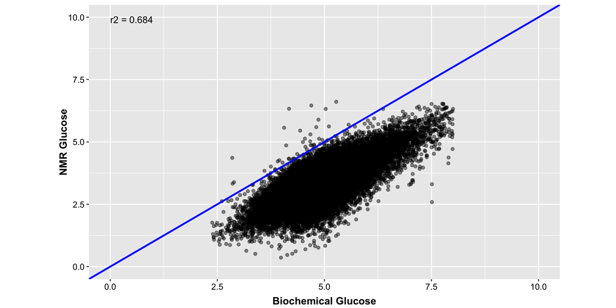

#### Examine NMR glucose & assay performance by 24HR

Stratified by fasting time

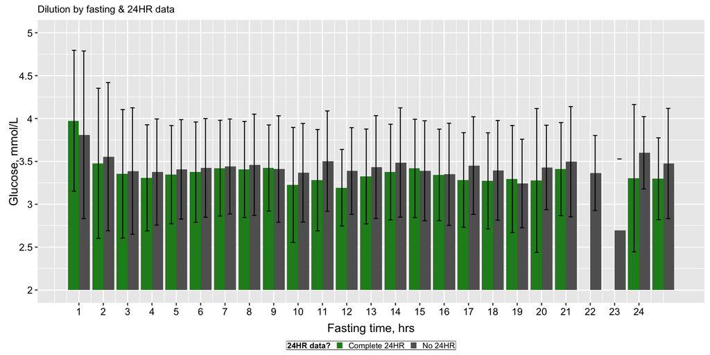

### Run main regressions & sensitivity models adjusting for spectrometer

#### Adjust for dilution fraction/aliquot and SES

Total sample

TAS2R38 diplotype & NMR RG with assay perf adjustment

| Model | Exposure | N | Beta_95CI | P | F.test_P | T.test_P |
| --- | --- | --- | --- | --- | --- | --- |
| Base | AVI/AVI | 17743 | NA (NA, NA) | - | 0.716921 | 0.309105 |
| Base | AVI/PAV | 25474 | -0.006 (-0.017, 0.006) | 0.324322086989337 | - | - |
| Base | PAV/PAV | 9172 | -0.007 (-0.021, 0.008) | 0.372904751737254 | - | - |
| Diet | AVI/AVI | 17743 | NA (NA, NA) | - | 0.714115 | 0.320642 |
| Diet | AVI/PAV | 25474 | -0.005 (-0.016, 0.006) | 0.356296700401259 | - | - |
| Diet | PAV/PAV | 9172 | -0.007 (-0.021, 0.008) | 0.377837301258727 | - | - |
| SES | AVI/AVI | 15408 | NA (NA, NA) | - | 0.683281 | 0.371263 |
| SES | AVI/PAV | 22160 | -0.006 (-0.018, 0.006) | 0.346738197013908 | - | - |
| SES | PAV/PAV | 7915 | -0.006 (-0.022, 0.01) | 0.447415506007361 | - | - |
| Assay | AVI/AVI | 15408 | NA (NA, NA) | - | 0.68327 | 0.369499 |
| Assay | AVI/PAV | 22160 | -0.006 (-0.018, 0.006) | 0.352225371202117 | - | - |
| Assay | PAV/PAV | 7915 | -0.006 (-0.022, 0.01) | 0.443241391773222 | - | - |
| SES+Fib2Carb | AVI/AVI | 6608 | NA (NA, NA) | - | 0.910021 | 0.92587 |
| SES+Fib2Carb | AVI/PAV | 9226 | -0.001 (-0.019, 0.017) | 0.929373331017548 | - | - |
| SES+Fib2Carb | PAV/PAV | 3337 | 0.002 (-0.022, 0.026) | 0.891925723559245 | - | - |
| Fib2Carb+Assay | AVI/AVI | 6608 | NA (NA, NA) | - | 0.910002 | 0.921924 |
| Fib2Carb+Assay | AVI/PAV | 9226 | -0.001 (-0.019, 0.018) | 0.949115741389651 | - | - |
| Fib2Carb+Assay | PAV/PAV | 3337 | 0.002 (-0.022, 0.026) | 0.893358206299661 | - | - |

TAS2R38 diplotype & NMR 2hr glucose with assay perf adjustment

| Model | Exposure | N | Beta_95CI | P | F.test_P | T.test_P |
| --- | --- | --- | --- | --- | --- | --- |
| Base | AVI/AVI | 4740 | NA (NA, NA) | - | 0.234311 | 0.327766 |
| Base | AVI/PAV | 6772 | -0.022 (-0.049, 0.006) | 0.118339274913369 | - | - |
| Base | PAV/PAV | 2403 | -0.012 (-0.048, 0.024) | 0.506125702689657 | - | - |
| Diet | AVI/AVI | 4740 | NA (NA, NA) | - | 0.228612 | 0.315374 |
| Diet | AVI/PAV | 6772 | -0.019 (-0.046, 0.008) | 0.168446886463995 | - | - |
| Diet | PAV/PAV | 2403 | -0.014 (-0.05, 0.022) | 0.452520463693793 | - | - |
| SES | AVI/AVI | 4195 | NA (NA, NA) | - | 0.191893 | 0.20419 |
| SES | AVI/PAV | 6047 | -0.023 (-0.052, 0.006) | 0.118606973449842 | - | - |
| SES | PAV/PAV | 2123 | -0.02 (-0.058, 0.019) | 0.31512386369345 | - | - |
| Assay | AVI/AVI | 4195 | NA (NA, NA) | - | 0.191896 | 0.206143 |
| Assay | AVI/PAV | 6047 | -0.023 (-0.052, 0.006) | 0.115054869644999 | - | - |
| Assay | PAV/PAV | 2123 | -0.019 (-0.057, 0.019) | 0.320587681992584 | - | - |
| SES+Fib2Carb | AVI/AVI | 1720 | NA (NA, NA) | - | 0.866278 | 0.960149 |
| SES+Fib2Carb | AVI/PAV | 2423 | 0 (-0.045, 0.046) | 0.99433967672941 | - | - |
| SES+Fib2Carb | PAV/PAV | 853 | 0.002 (-0.059, 0.062) | 0.954993745088196 | - | - |
| Fib2Carb+Assay | AVI/AVI | 1720 | NA (NA, NA) | - | 0.866287 | 0.955875 |
| Fib2Carb+Assay | AVI/PAV | 2423 | 0 (-0.045, 0.046) | 0.998198293780225 | - | - |
| Fib2Carb+Assay | PAV/PAV | 853 | 0.002 (-0.058, 0.062) | 0.948764671177886 | - | - |

Run in models stratified by 24HR data

TAS2R38 diplotype & NMR RG with assay perf adjustment = by 24hr

| Model | Exposure | N | Beta_95CI | P | F.test_P | T.test_P |
| --- | --- | --- | --- | --- | --- | --- |
| Complete 24HR: Base | AVI/AVI | 7328 | NA (NA, NA) | - | 0.955123 | 0.745697 |
| Complete 24HR: Base | AVI/PAV | 10278 | -0.003 (-0.02, 0.014) | 0.721515070004954 | - | - |
| Complete 24HR: Base | PAV/PAV | 3735 | -0.003 (-0.026, 0.02) | 0.786765374464178 | - | - |
| Complete 24HR: Diet | AVI/AVI | 7328 | NA (NA, NA) | - | 0.954553 | 0.729102 |
| Complete 24HR: Diet | AVI/PAV | 10278 | -0.003 (-0.02, 0.014) | 0.746823170325897 | - | - |
| Complete 24HR: Diet | PAV/PAV | 3735 | -0.004 (-0.026, 0.019) | 0.75937928565003 | - | - |
| Complete 24HR: SES | AVI/AVI | 6618 | NA (NA, NA) | - | 0.916995 | 0.869664 |
| Complete 24HR: SES | AVI/PAV | 9241 | 0 (-0.018, 0.018) | 0.989657637065185 | - | - |
| Complete 24HR: SES | PAV/PAV | 3342 | 0.002 (-0.022, 0.026) | 0.85109017917355 | - | - |
| Complete 24HR: Assay | AVI/AVI | 6618 | NA (NA, NA) | - | 0.916977 | 0.866564 |
| Complete 24HR: Assay | AVI/PAV | 9241 | 0 (-0.018, 0.018) | 0.970744117278909 | - | - |
| Complete 24HR: Assay | PAV/PAV | 3342 | 0.002 (-0.022, 0.026) | 0.853187927768205 | - | - |
| Complete 24HR: SES+Fib2Carb | AVI/AVI | 6608 | NA (NA, NA) | - | 0.911856 | 0.924896 |
| Complete 24HR: SES+Fib2Carb | AVI/PAV | 9225 | -0.001 (-0.019, 0.017) | 0.933018885427238 | - | - |
| Complete 24HR: SES+Fib2Carb | PAV/PAV | 3337 | 0.002 (-0.022, 0.026) | 0.891905665730027 | - | - |
| Complete 24HR: Fib2Carb+Assay | AVI/AVI | 6608 | NA (NA, NA) | - | 0.911838 | 0.920933 |
| Complete 24HR: Fib2Carb+Assay | AVI/PAV | 9225 | -0.001 (-0.019, 0.018) | 0.952770859858881 | - | - |
| Complete 24HR: Fib2Carb+Assay | PAV/PAV | 3337 | 0.002 (-0.022, 0.026) | 0.893319219175032 | - | - |

TAS2R38 diplotype & NMR 2hr glucose with assay perf adjustment - by 24HR

| Model | Exposure | N | Beta_95CI | P | F.test_P | T.test_P |
| --- | --- | --- | --- | --- | --- | --- |
| Complete 24HR: Base | AVI/AVI | 1895 | NA (NA, NA) | - | 0.861925 | 0.862929 |
| Complete 24HR: Base | AVI/PAV | 2656 | -0.003 (-0.047, 0.041) | 0.893879433087276 | - | - |
| Complete 24HR: Base | PAV/PAV | 942 | -0.005 (-0.063, 0.053) | 0.872530562144628 | - | - |
| Complete 24HR: Diet | AVI/AVI | 1895 | NA (NA, NA) | - | 0.859816 | 0.968488 |
| Complete 24HR: Diet | AVI/PAV | 2656 | -0.001 (-0.044, 0.043) | 0.972156722275555 | - | - |
| Complete 24HR: Diet | PAV/PAV | 942 | -0.001 (-0.059, 0.057) | 0.971812841533773 | - | - |
| Complete 24HR: SES | AVI/AVI | 1723 | NA (NA, NA) | - | 0.900149 | 0.91725 |
| Complete 24HR: SES | AVI/PAV | 2426 | 0.002 (-0.043, 0.048) | 0.922752470769386 | - | - |
| Complete 24HR: SES | PAV/PAV | 853 | 0.003 (-0.058, 0.063) | 0.927309201578507 | - | - |
| Complete 24HR: Assay | AVI/AVI | 1723 | NA (NA, NA) | - | 0.900156 | 0.914108 |
| Complete 24HR: Assay | AVI/PAV | 2426 | 0.002 (-0.043, 0.048) | 0.928114114407423 | - | - |
| Complete 24HR: Assay | PAV/PAV | 853 | 0.003 (-0.057, 0.064) | 0.921893172333544 | - | - |
| Complete 24HR: SES+Fib2Carb | AVI/AVI | 1720 | NA (NA, NA) | - | 0.870637 | 0.959595 |
| Complete 24HR: SES+Fib2Carb | AVI/PAV | 2422 | 0 (-0.045, 0.046) | 0.989598965015472 | - | - |
| Complete 24HR: SES+Fib2Carb | PAV/PAV | 853 | 0.002 (-0.059, 0.062) | 0.955845959469049 | - | - |
| Complete 24HR: Fib2Carb+Assay | AVI/AVI | 1720 | NA (NA, NA) | - | 0.870646 | 0.95533 |
| Complete 24HR: Fib2Carb+Assay | AVI/PAV | 2422 | 0 (-0.045, 0.046) | 0.9937698513144 | - | - |
| Complete 24HR: Fib2Carb+Assay | PAV/PAV | 853 | 0.002 (-0.059, 0.062) | 0.949525839624742 | - | - |

#### End of sensitivity analyses for assay performance